# R Notebook

Below are a series of analyses completed on the following data: * Microbial Biomass C * Microbial Biomass N * Non-purgeable Organic Carbon (NPOC) * Dissolved Organic Nitrogen (DON) * Extracellular Enzymes * Microbial Efficiency (enzyme activity per unit microbial biomass)

Analyses include repeated-measures ANOVA and one-way ANOVA, completed on the data averaged by plots, showing no averages, and/or related to the baseline data (PRE GrazeTime)

*Between-subjects variable: Treatment (each plot has a different treatment)* *Within-subjects variable: GrazeTime (each plot repeated four GrazeTimes)*

```r
# Preparing the data
require(ggplot2)
require(tidyverse)
require(dplyr)
source("https://raw.githubusercontent.com/EmilyB17/grazing_soil_microbes/master/R/prepData.R")
toc <- prepData(read.table(file = "https://raw.githubusercontent.com/EmilyB17/grazing_soil_microbes/master/data/NPOC_DON_MBC.txt", sep = "\t", header = TRUE, stringsAsFactors = TRUE))
```

Working with Microbial Biomass Carbon (MBC) **First: repeated-measures ANOVA on all data averaged by Plot and relative to the PRE baseline**

The printout shows both the ANOVA summary and the pairwise t test with Bonferroni correction

```r
# ---- Microbial Biomass C ----
mbc <- toc[, -c(6:15, 17)]
# Examine data relative to the PRE baseline
all <- merge(aggregate(mbc_mgg ~ Plot, data = mbc[mbc$GrazeTime %in% "PRE",], mean),
             aggregate(mbc_mgg ~ GrazeTime + Plot + Treatment,
                       data = mbc[!mbc$GrazeTime %in% "PRE",], mean),
             by = "Plot")
all$delta <- all$mbc_mgg.y - all$mbc_mgg.x
all$mbc_mgg.x <- NULL
all$mbc_mgg.y <- NULL
# Now the data is averaged by Plot, and "delta" is the difference of the average of that plot from the average of the same plot at the PRE baseline
# plot
ggplot(data = all, aes(x = Treatment, y = delta, colour = Treatment)) +
  geom_boxplot() +
  facet_wrap(~ GrazeTime)
# perform repeated-measures ANOVA
mod.mbc <- aov(all$delta ~ all$Treatment * all$GrazeTime + Error(all$delta / all$GrazeTime))
```

```
the response appeared on the right-hand side and was droppedproblem with term 1 in model.matrix: no columns are assigned
```

```r
summary(mod.mbc)
```

```
Error: all$delta:all$GrazeTime
              Df Sum Sq Mean Sq
all$Treatment  2  78999   39500

Error: Within
                            Df Sum Sq Mean Sq F value Pr(>F)
all$Treatment                2  70333   35167   1.177  0.325
all$GrazeTime                2  54300   27150   0.909  0.416
all$Treatment:all$GrazeTime  4   1049     262   0.009  1.000
Residuals                   25 747069   29883
```

```r
# Bonferroni test - is the most conservative
with(all, pairwise.t.test(delta, Treatment, p.adjust.method = "bonferroni", paired = TRUE))
```

```
    Pairwise comparisons using paired t tests

data:  delta and Treatment

   HI   LO
LO 0.92 -
NO 0.97 0.39

P value adjustment method: bonferroni
```

```r
with(all, pairwise.t.test(delta, GrazeTime, p.adjust.method = "bonferroni", paired = TRUE)) # 24H and 4Wk are significant
```

```
    Pairwise comparisons using paired t tests

data:  delta and GrazeTime

    24H   1WK
1WK 0.262 -
4WK 0.018 0.959

P value adjustment method: bonferroni
```

Now we will look at the raw MBC data and do a single one-way ANOVA for each GrazeTime, comparing only the treatments to each other.

Only the PRE GrazeTime has significance. However, the pairwise t test for PRE does not show significance.

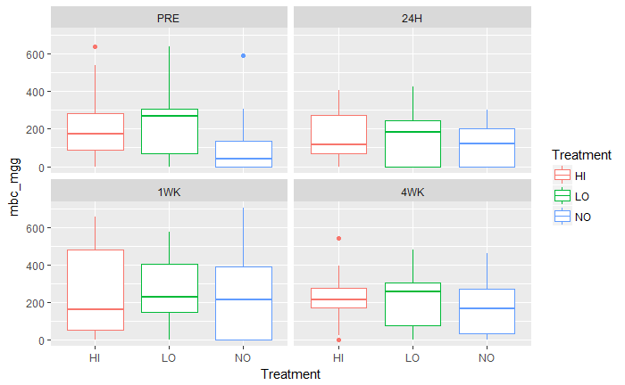

```r
# Loop to examine each Treatment by GrazeTime - no averaging
ggplot(data = mbc, aes(x = Treatment, y = mbc_mgg, colour = Treatment)) +
  geom_boxplot() +
  facet_wrap(~ GrazeTime)
```

```r
grz <- unique(mbc$GrazeTime)
# save the model objects
mods<- list()
for(i in 1:length(grz)) {
  mods<- c(mods, list(aov(mbc_mgg ~ Treatment,
                          data = filter(mbc, GrazeTime == grz[i]))))

}
names(mods)<- grz
lapply(mods, summary) # Significance: PRE
```

```
$PRE
            Df  Sum Sq Mean Sq F value Pr(>F)
Treatment    2  229378  114689    3.95 0.0247 *
Residuals   57 1655008   29035
---
Signif. codes:  0 ‘***’ 0.001 ‘**’ 0.01 ‘*’ 0.05 ‘.’ 0.1 ‘ ’ 1

$`24H`
            Df Sum Sq Mean Sq F value Pr(>F)
Treatment    2  25940   12970   0.826  0.443
Residuals   57 894549   15694

$`1WK`
            Df  Sum Sq Mean Sq F value Pr(>F)
Treatment    2   10892    5446   0.105    0.9
Residuals   50 2587946   51759
7 observations deleted due to missingness

$`4WK`
            Df  Sum Sq Mean Sq F value Pr(>F)
Treatment    2   26270   13135   0.686  0.508
Residuals   57 1090811   19137
```

```r
# Individual post-hoc tests
with(mbc, pairwise.t.test(mbc_mgg, Treatment, p.adjust.method = "bonferroni", paired = TRUE)) # no significance
```

```
    Pairwise comparisons using paired t tests

data:  mbc_mgg and Treatment

   HI   LO
LO 0.93 -
NO 0.65 0.12

P value adjustment method: bonferroni
```

Next: Doing the same singlular one-way ANOVAS with the data relative to the PRE baseline data. There is no significance

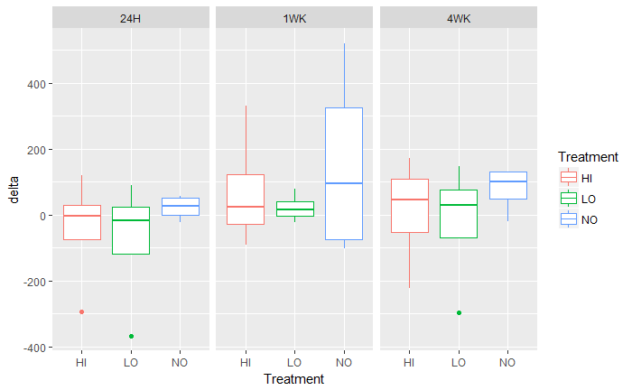

```r
## Same loop but relative to PRE baseline
ggplot(data = all, aes(x = Treatment, y = delta, colour = Treatment)) +
  geom_boxplot() +
  facet_wrap(~ GrazeTime)
```

```r
grz <- unique(all$GrazeTime)
# save the model objects
mods<- list()
for(i in 1:length(grz)) {
  mods<- c(mods, list(aov(delta ~ Treatment,
                          data = filter(all, GrazeTime == grz[i]))))

}
names(mods)<- grz
lapply(mods, summary) # No significance
```

```
$`4WK`
            Df Sum Sq Mean Sq F value Pr(>F)
Treatment    2  20739   10369   0.439  0.658
Residuals    9 212414   23602

$`24H`
            Df Sum Sq Mean Sq F value Pr(>F)
Treatment    2  20903   10452   0.433  0.661
Residuals    9 217320   24147

$`1WK`
            Df Sum Sq Mean Sq F value Pr(>F)
Treatment    2  34607   17304   0.426  0.665
Residuals    9 365258   40584
```

*Microbial Biomass N (MBN)*

This follows the exact procedures as above.

For the repeated-measures ANOVA where averaged data is considered relative to the PRE baseline, the only significance is with GrazeTime, and all GrazeTimes are strongly significant to each other.

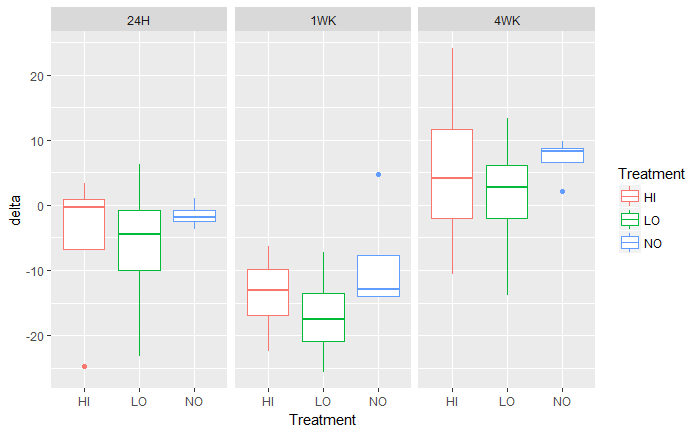

```r
# ---- Microbial Biomass N ----
mbn <- toc[, -c(6:16)]
# Examine data relative to the PRE baseline
all <- merge(aggregate(mbn_mgg ~ Plot, data = mbn[mbn$GrazeTime %in% "PRE",], mean),
             aggregate(mbn_mgg ~ GrazeTime + Plot + Treatment,
                       data = mbn[!mbn$GrazeTime %in% "PRE",], mean),
             by = "Plot")
all$delta <- all$mbn_mgg.y - all$mbn_mgg.x
all$mbn_mgg.x <- NULL
all$mbn_mgg.y <- NULL
# Now the data is averaged by Plot, and "delta" is the difference of the average of that plot from the average of the same plot at the PRE baseline
# plot
ggplot(data = all, aes(x = Treatment, y = delta, colour = Treatment)) +
  geom_boxplot() +
  facet_wrap(~ GrazeTime)
```

```r
# perform repeated-measures ANOVA
mod.mbn <- aov(all$delta ~ all$Treatment * all$GrazeTime + Error(all$delta / all$GrazeTime))
```

```
the response appeared on the right-hand side and was droppedproblem with term 1 in model.matrix: no columns are assigned
```

```r
summary(mod.mbn) # GrazeTime is significant
```

```
Error: all$delta:all$GrazeTime
              Df Sum Sq Mean Sq
all$Treatment  2  317.4   158.7

Error: Within
                            Df Sum Sq Mean Sq F value  Pr(>F)
all$Treatment                2  216.7   108.4   1.131 0.33882
all$GrazeTime                2 1738.3   869.1   9.068 0.00109 **
all$Treatment:all$GrazeTime  4   71.3    17.8   0.186 0.94353
Residuals                   25 2396.1    95.8
---
Signif. codes:  0 ‘***’ 0.001 ‘**’ 0.01 ‘*’ 0.05 ‘.’ 0.1 ‘ ’ 1
```

```r
# Bonferroni test - is the most conservative
with(all, pairwise.t.test(delta, Treatment, p.adjust.method = "bonferroni", paired = TRUE)) # no significance
```

```
    Pairwise comparisons using paired t tests

data:  delta and Treatment

   HI   LO
LO 1.00 -
NO 1.00 0.27

P value adjustment method: bonferroni
```

```r
with(all, pairwise.t.test(delta, GrazeTime, p.adjust.method = "bonferroni", paired = TRUE)) # All are significant (strongly)
```

```
    Pairwise comparisons using paired t tests

data:  delta and GrazeTime

    24H    1WK
1WK 0.0018 -
4WK 0.0017 4.1e-05

P value adjustment method: bonferroni
```

Next: singular one-way ANOVAs (one ANOVA per GrazeTime, examining only Treatment with no averaging).

There is no significance between Treatments for any GrazeTime.

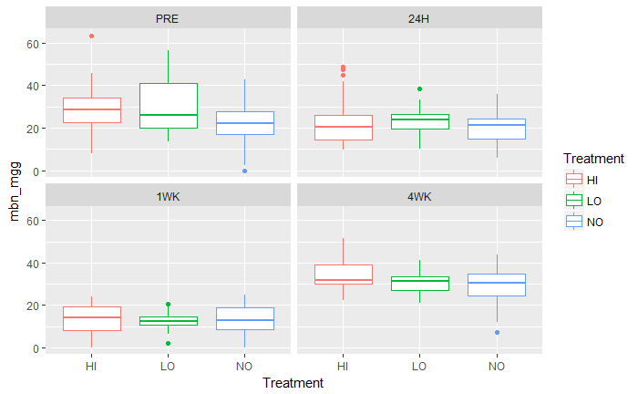

```r
# Loop to examine each Treatment by GrazeTime - no averaging
ggplot(data = mbn, aes(x = Treatment, y = mbn_mgg, colour = Treatment)) +
  geom_boxplot() +
  facet_wrap(~ GrazeTime)
```

```r
grz <- unique(mbn$GrazeTime)
# save the model objects
mods<- list()
for(i in 1:length(grz)) {
  mods<- c(mods, list(aov(mbn_mgg ~ Treatment,
                          data = filter(mbn, GrazeTime == grz[i]))))

}
names(mods)<- grz
lapply(mods, summary) # No significance
```

```
$PRE
            Df Sum Sq Mean Sq F value Pr(>F)
Treatment    2    685   342.7   2.389  0.101
Residuals   57   8177   143.5

$`24H`
            Df Sum Sq Mean Sq F value Pr(>F)
Treatment    2    105   52.28     0.6  0.552
Residuals   57   4970   87.19

$`1WK`
            Df Sum Sq Mean Sq F value Pr(>F)
Treatment    2    2.9    1.44   0.033  0.968
Residuals   50 2173.2   43.46
7 observations deleted due to missingness

$`4WK`
            Df Sum Sq Mean Sq F value Pr(>F)
Treatment    2    282  141.20   2.215  0.118
Residuals   57   3634   63.75
```

Singular one-way ANOVAS with the averaged data: Average the data by Plot and compare to the PRE Baseline.

Again, there is no significance between Treatment at any GrazeTime

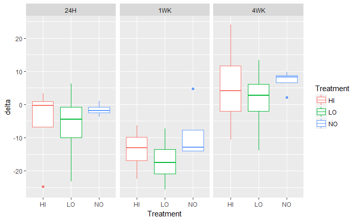

```r
## Same loop but relative to PRE baseline
ggplot(data = all, aes(x = Treatment, y = delta, colour = Treatment)) +
  geom_boxplot() +
  facet_wrap(~ GrazeTime)
```

```r
grz <- unique(all$GrazeTime)
# save the model objects
mods<- list()
for(i in 1:length(grz)) {
  mods<- c(mods, list(aov(delta ~ Treatment,
                          data = filter(all, GrazeTime == grz[i]))))

}
names(mods)<- grz
lapply(mods, summary) # No significance
```

```
$`4WK`
            Df Sum Sq Mean Sq F value Pr(>F)
Treatment    2   72.1   36.04   0.309  0.742
Residuals    9 1049.1  116.56

$`24H`
            Df Sum Sq Mean Sq F value Pr(>F)
Treatment    2   52.7   26.33   0.245  0.787
Residuals    9  965.6  107.29

$`1WK`
            Df Sum Sq Mean Sq F value Pr(>F)
Treatment    2  135.8   67.88    1.08   0.38
Residuals    9  565.9   62.87
```

*Non-Purgeable Organic Carbon (NPOC)*

NOTE: This is similar to total organic carbon but the procedure burns off inorganic carbon

Same procedure as above: first perform repeated-measures ANOVA on averaged NPOC data relative to the PRE baseline.

The ANOVA shows significance but the post-hoc Bonferroni test does not.

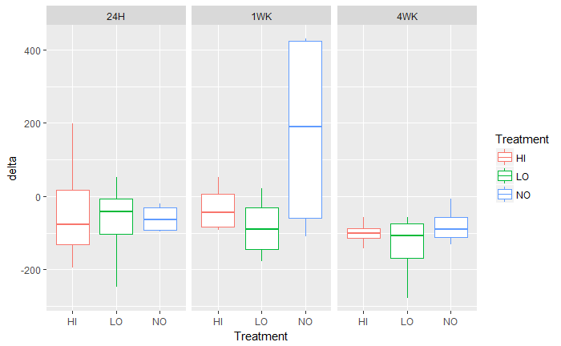

```r
# ---- NPOC ----
npoc <- toc[, -c(6:7, 9:17)]
# Examine data relative to the PRE baseline
all <- merge(aggregate(NPOC_t0Nmin_mgg ~ Plot, data = npoc[npoc$GrazeTime %in% "PRE",], mean),
             aggregate(NPOC_t0Nmin_mgg ~ GrazeTime + Plot + Treatment,
                       data = npoc[!npoc$GrazeTime %in% "PRE",], mean),
             by = "Plot")
all$delta <- all$NPOC_t0Nmin_mgg.y - all$NPOC_t0Nmin_mgg.x
all$NPOC_t0Nmin_mgg.x <- NULL
all$NPOC_t0Nmin_mgg.y <- NULL
# Now the data is averaged by Plot, and "delta" is the difference of the average of that plot from the average of the same plot at the PRE baseline
# plot
ggplot(data = all, aes(x = Treatment, y = delta, colour = Treatment)) +
  geom_boxplot() +
  facet_wrap(~ GrazeTime)
```

```r
# perform repeated-measures ANOVA
mod.npoc <- aov(all$delta ~ all$Treatment * all$GrazeTime + Error(all$delta / all$GrazeTime))
```

```
the response appeared on the right-hand side and was droppedproblem with term 1 in model.matrix: no columns are assigned
```

```r
summary(mod.npoc)
```

```
Error: all$delta:all$GrazeTime
              Df Sum Sq Mean Sq
all$Treatment  2 215334  107667

Error: Within
                            Df Sum Sq Mean Sq F value   Pr(>F)
all$Treatment                2  24319   12160   1.170 0.326857
all$GrazeTime                2 213209  106605  10.256 0.000559 ***
all$Treatment:all$GrazeTime  4  15717    3929   0.378 0.822140
Residuals                   25 259871   10395
---
Signif. codes:  0 ‘***’ 0.001 ‘**’ 0.01 ‘*’ 0.05 ‘.’ 0.1 ‘ ’ 1
```

```r
# Bonferroni test - is the most conservative
with(all, pairwise.t.test(delta, Treatment, p.adjust.method = "bonferroni", paired = TRUE)) # no significance
```

```
    Pairwise comparisons using paired t tests

data:  delta and Treatment

   HI   LO
LO 1.00 -
NO 0.54 0.42

P value adjustment method: bonferroni
```

```r
with(all, pairwise.t.test(delta, GrazeTime, p.adjust.method = "bonferroni", paired = TRUE)) # no significance
```

```
    Pairwise comparisons using paired t tests

data:  delta and GrazeTime

    24H  1WK
1WK 0.74 -
4WK 0.42 0.11

P value adjustment method: bonferroni
```

Next, compare singular one-way ANOVAs with all data (no averaging).

The ANOVA shows a significance between Treatments in the 1WK GrazeTime but the Bonferroni test shows no significance.

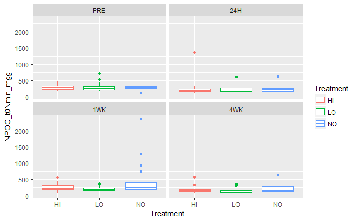

```r
# Loop to examine each Treatment by GrazeTime - no averaging
ggplot(data = npoc, aes(x = Treatment, y = NPOC_t0Nmin_mgg, colour = Treatment)) +
  geom_boxplot() +
  facet_wrap(~ GrazeTime)
```

```r
grz <- unique(npoc$GrazeTime)
# save the model objects
mods<- list()
for(i in 1:length(grz)) {
  mods<- c(mods, list(aov(NPOC_t0Nmin_mgg ~ Treatment,
                          data = filter(npoc, GrazeTime == grz[i]))))

}
names(mods)<- grz
lapply(mods, summary) # Significance: PRE
```

```
$PRE
            Df Sum Sq Mean Sq F value Pr(>F)
Treatment    2    266     133   0.013  0.987
Residuals   57 588345   10322

$`24H`
            Df  Sum Sq Mean Sq F value Pr(>F)
Treatment    2   13292    6646   0.205  0.816
Residuals   57 1850997   32474

$`1WK`
            Df  Sum Sq Mean Sq F value Pr(>F)
Treatment    2  733456  366728    3.56 0.0349 *
Residuals   57 5871044  103001
---
Signif. codes:  0 ‘***’ 0.001 ‘**’ 0.01 ‘*’ 0.05 ‘.’ 0.1 ‘ ’ 1

$`4WK`
            Df Sum Sq Mean Sq F value Pr(>F)
Treatment    2  31993   15996   1.065  0.351
Residuals   57 855815   15014
```

```r
# Individual post-hoc tests
with(npoc, pairwise.t.test(NPOC_t0Nmin_mgg, Treatment, p.adjust.method = "bonferroni", paired = TRUE)) # no significance
```

```
    Pairwise comparisons using paired t tests

data:  NPOC_t0Nmin_mgg and Treatment

   HI   LO
LO 0.47 -
NO 0.68 0.08

P value adjustment method: bonferroni
```

Finally, the singular one-way ANOVAs with averaged data relative to the PRE baseline.

The ANOVAs show no significance between Treatments at any GrazeTime.

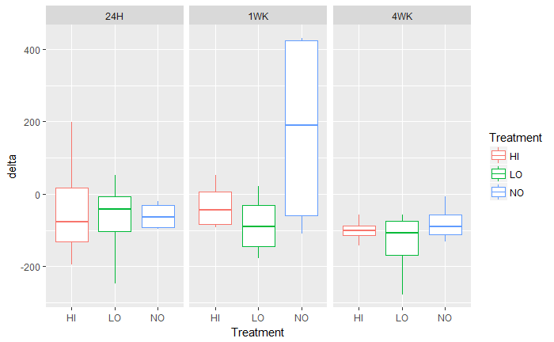

```r
## Same loop but relative to PRE baseline
ggplot(data = all, aes(x = Treatment, y = delta, colour = Treatment)) +
  geom_boxplot() +
  facet_wrap(~ GrazeTime)
```

```r
grz <- unique(all$GrazeTime)
# save the model objects
mods<- list()
for(i in 1:length(grz)) {
  mods<- c(mods, list(aov(delta ~ Treatment,
                          data = filter(all, GrazeTime == grz[i]))))

}
names(mods)<- grz
lapply(mods, summary) # No significance
```

```
$`4WK`
            Df Sum Sq Mean Sq F value Pr(>F)
Treatment    2   6800    3400   0.735  0.506
Residuals    9  41630    4626

$`24H`
            Df Sum Sq Mean Sq F value Pr(>F)
Treatment    2   2149    1075    0.07  0.933
Residuals    9 139107   15456

$`1WK`
            Df Sum Sq Mean Sq F value Pr(>F)
Treatment    2 150965   75483   2.325  0.153
Residuals    9 292185   32465
```

*Dissolved Organic Nitrogen - DON*

First, the repeated-measures ANOVA with averaged data by Plot relative to the PRE baseline.

The ANOVA shows GrazeTime is significant, and the post-hoc test shows significance between 24H and 4WK, and 1WK and 4WK

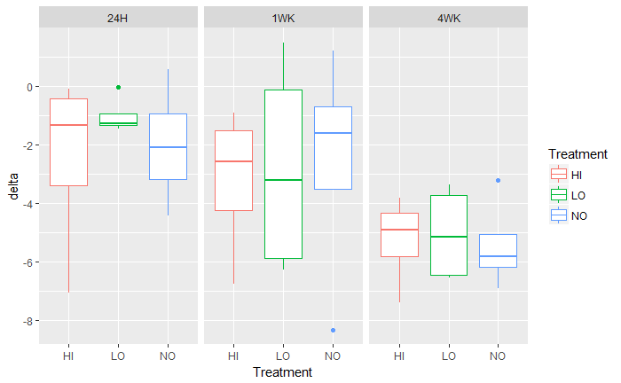

```r
don <- toc[, -c(6:8, 10:17)]
# Examine data relative to the PRE baseline
all <- merge(aggregate(DON_t0Nmin_mgg ~ Plot, data = don[don$GrazeTime %in% "PRE",], mean),
             aggregate(DON_t0Nmin_mgg ~ GrazeTime + Plot + Treatment,
                       data = don[!don$GrazeTime %in% "PRE",], mean),
             by = "Plot")
all$delta <- all$DON_t0Nmin_mgg.y - all$DON_t0Nmin_mgg.x
all$mbn_mgg.x <- NULL
all$mbn_mgg.y <- NULL
# Now the data is averaged by Plot, and "delta" is the difference of the average of that plot from the average of the same plot at the PRE baseline
# plot
ggplot(data = all, aes(x = Treatment, y = delta, colour = Treatment)) +
  geom_boxplot() +
  facet_wrap(~ GrazeTime)
```

```r
# perform repeated-measures ANOVA
mod.don <- aov(all$delta ~ all$Treatment * all$GrazeTime + Error(all$delta / all$GrazeTime))
```

```
the response appeared on the right-hand side and was droppedproblem with term 1 in model.matrix: no columns are assigned
```

```r
summary(mod.don) # significance between GrazeTimes
```

```
Error: all$delta:all$GrazeTime
              Df Sum Sq Mean Sq
all$Treatment  2  53.31   26.66

Error: Within
                            Df Sum Sq Mean Sq F value  Pr(>F)
all$Treatment                2   4.71    2.36   0.485 0.62113
all$GrazeTime                2  80.68   40.34   8.307 0.00171 **
all$Treatment:all$GrazeTime  4   2.00    0.50   0.103 0.98046
Residuals                   25 121.40    4.86
---
Signif. codes:  0 ‘***’ 0.001 ‘**’ 0.01 ‘*’ 0.05 ‘.’ 0.1 ‘ ’ 1
```

```r
# Bonferroni test - is the most conservative
with(all, pairwise.t.test(delta, Treatment, p.adjust.method = "bonferroni", paired = TRUE)) # no significance
```

```
    Pairwise comparisons using paired t tests

data:  delta and Treatment

   HI LO
LO 1  -
NO 1  1

P value adjustment method: bonferroni
```

```r
with(all, pairwise.t.test(delta, GrazeTime, p.adjust.method = "bonferroni", paired = TRUE)) # 1WK-4Wk and 24H-4Wk are significant
```

```
    Pairwise comparisons using paired t tests

data:  delta and GrazeTime

    24H    1WK
1WK 0.6646 -
4WK 0.0021 0.0179

P value adjustment method: bonferroni
```

Next, the singular one-way ANOVAs for Treatment by each GrazeTime.

The ANOVAs show no significance between Treatment at any GrazeTime

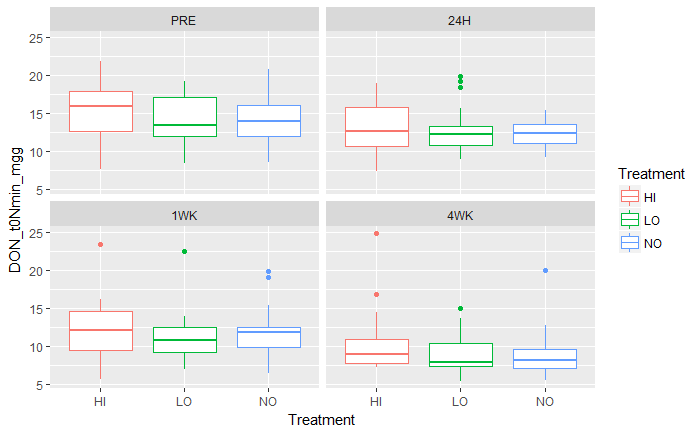

```r
# Loop to examine each Treatment by GrazeTime - no averaging
ggplot(data = don, aes(x = Treatment, y = DON_t0Nmin_mgg, colour = Treatment)) +
  geom_boxplot() +
  facet_wrap(~ GrazeTime)
```

```r
grz <- unique(don$GrazeTime)
# save the model objects
mods<- list()
for(i in 1:length(grz)) {
  mods<- c(mods, list(aov(DON_t0Nmin_mgg ~ Treatment,
                          data = filter(don, GrazeTime == grz[i]))))

}
names(mods)<- grz
lapply(mods, summary) # No significance
```

```
$PRE
            Df Sum Sq Mean Sq F value Pr(>F)
Treatment    2   27.9   13.96   1.244  0.296
Residuals   57  639.5   11.22

$`24H`
            Df Sum Sq Mean Sq F value Pr(>F)
Treatment    2    8.4   4.214   0.511  0.603
Residuals   57  469.9   8.244

$`1WK`
            Df Sum Sq Mean Sq F value Pr(>F)
Treatment    2   13.4   6.725   0.523  0.595
Residuals   57  732.7  12.855

$`4WK`
            Df Sum Sq Mean Sq F value Pr(>F)
Treatment    2   26.8   13.41    1.17  0.318
Residuals   57  653.3   11.46
```

Finally, the singular one-way ANOVAs for the averaged DON data relative to the PRE baseline.

Again, the ANOVAs show no significance between Treatment at any GrazeTime

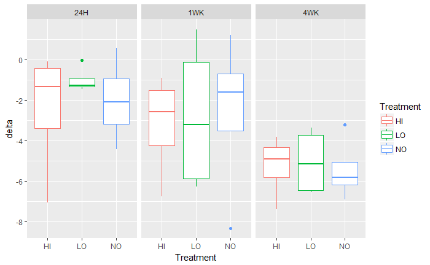

```r
## Same loop but relative to PRE baseline
ggplot(data = all, aes(x = Treatment, y = delta, colour = Treatment)) +
  geom_boxplot() +
  facet_wrap(~ GrazeTime)
```

```r
grz <- unique(all$GrazeTime)
# save the model objects
mods<- list()
for(i in 1:length(grz)) {
  mods<- c(mods, list(aov(delta ~ Treatment,
                          data = filter(all, GrazeTime == grz[i]))))

}
names(mods)<- grz
lapply(mods, summary) # No significance
```

```
$`4WK`
            Df Sum Sq Mean Sq F value Pr(>F)
Treatment    2  0.306  0.1529    0.06  0.943
Residuals    9 23.095  2.5661

$`24H`
            Df Sum Sq Mean Sq F value Pr(>F)
Treatment    2   4.40   2.202   0.437  0.659
Residuals    9  45.34   5.038

$`1WK`
            Df Sum Sq Mean Sq F value Pr(>F)
Treatment    2   0.79   0.393   0.031   0.97
Residuals    9 113.90  12.656
```

*Extracellular Enzymes*

There are 10 substrates that are analyzed as separate procedures.

First, the repeated-measures ANOVA of enzyme activity averaged by Plot, relative to the PRE baseline. The ANOVAs show significance between GrazeTimes for CBH, NAG, PER1, PHOS - these will have their own individual post-hoc tests.

```r
enz.vert <- prepData(read.table(file = "https://raw.githubusercontent.com/EmilyB17/grazing_soil_microbes/master/data/enzymes_vertical.txt", sep = "\t", header = TRUE, stringsAsFactors = TRUE))
# Examine data relative to the PRE baseline
all <- merge(aggregate(Enzyme_nm_g_hr ~ Plot + Substrate, data = enz.vert[enz.vert$GrazeTime %in% "PRE",], mean),
             aggregate(Enzyme_nm_g_hr ~ GrazeTime + Plot + Treatment + Substrate,
                       data = enz.vert[!enz.vert$GrazeTime %in% "PRE",], mean),
             by = c("Plot", "Substrate"))
all$delta <- all$Enzyme_nm_g_hr.y - all$Enzyme_nm_g_hr.x
all$Enzyme_nm_g_hr.x <- NULL
all$Enzyme_nm_g_hr.y <- NULL
# Now the data is averaged by Plot, and "delta" is the difference of the average of that plot from the average of the same plot at the PRE baseline
# Loop to look at each substrate in the repeated-measures ANOVA format
sub <- unique(enz.vert$Substrate)
# save the model objects
mods<- list()
for(i in 1:length(sub)) {
  mods<- c(mods, list(aov(delta ~ Treatment * GrazeTime + Error(delta / GrazeTime),
                          data = filter(all, Substrate == sub[i]))))
}
```

[output not shown]

```r
names(mods)<- sub
lapply(mods, summary)
```

```
$AG

Error: delta:GrazeTime
          Df Sum Sq Mean Sq
Treatment  2   1607   803.5

Error: Within
                    Df Sum Sq Mean Sq F value Pr(>F)
Treatment            2    159    79.3   0.236  0.792
GrazeTime            2    996   498.2   1.481  0.247
Treatment:GrazeTime  4    121    30.1   0.090  0.985
Residuals           25   8410   336.4

$BG

Error: delta:GrazeTime
          Df Sum Sq Mean Sq
Treatment  2  79168   39584

Error: Within
                    Df Sum Sq Mean Sq F value Pr(>F)
Treatment            2    239     119   0.007  0.993
GrazeTime            2  41471   20735   1.274  0.297
Treatment:GrazeTime  4   2934     734   0.045  0.996
Residuals           25 406826   16273

$BX

Error: delta:GrazeTime
          Df Sum Sq Mean Sq
Treatment  2  850.6   425.3

Error: Within
                    Df Sum Sq Mean Sq F value Pr(>F)
Treatment            2    528   263.9   0.313  0.734
GrazeTime            2   1254   627.1   0.744  0.485
Treatment:GrazeTime  4    476   119.0   0.141  0.965
Residuals           25  21070   842.8

$CBH
```

[output cut: 84 more lines]

```

$PHOS

Error: delta:GrazeTime
          Df Sum Sq Mean Sq
Treatment  2  62348   31174

Error: Within
                    Df Sum Sq Mean Sq F value  Pr(>F)
Treatment            2   8373    4187   0.812 0.45521
GrazeTime            2  73111   36555   7.093 0.00363 **
Treatment:GrazeTime  4  14721    3680   0.714 0.59017
Residuals           25 128852    5154
---
Signif. codes:  0 ‘***’ 0.001 ‘**’ 0.01 ‘*’ 0.05 ‘.’ 0.1 ‘ ’ 1
```

```r
# CBH, NAG, PER1, PHOS: GrazeTime
```

```r
# CBH, NAG, PER1, PHOS: GrazeTime
# Do individual post-hoc tests for the substrates that showed significance with GrazeTime
## CBH
# plot
ggplot(data = enz.vert[enz.vert$Substrate %in% "CBH",],
       aes(x = Treatment, y = delta, colour = Treatment)) +
  geom_boxplot() +
  facet_wrap(~ GrazeTime) +
  ggtitle("CBH")
```

[output not shown]

*Microbial Efficiency* Enzyme activity per unit microbial biomass

Start with repeated-measures ANOVA with averaged data by Plot relative to PRE baseline.